# COVID-19 Tweet Analysis

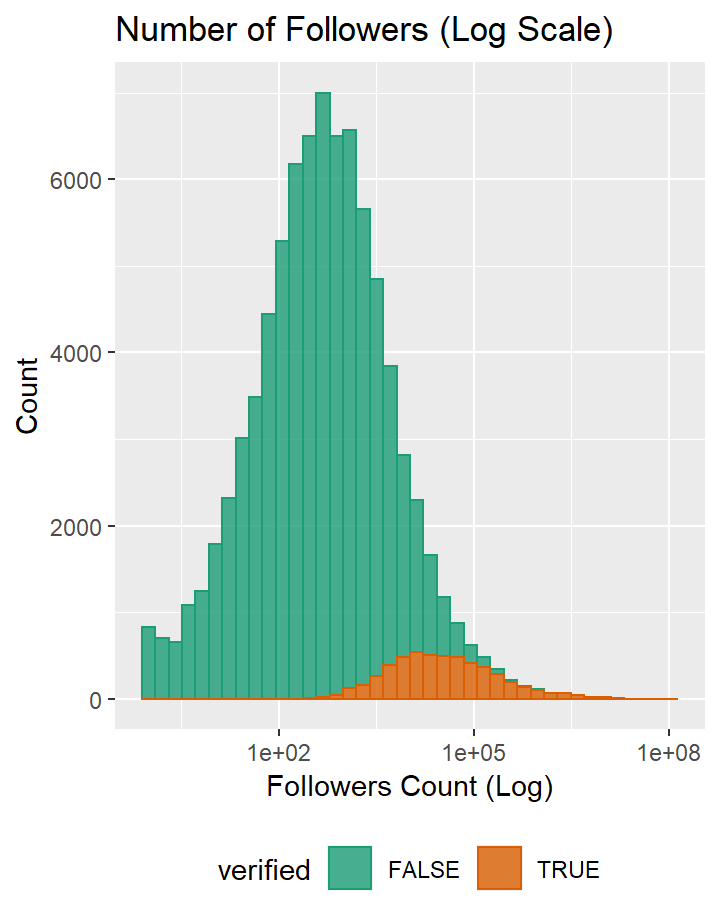

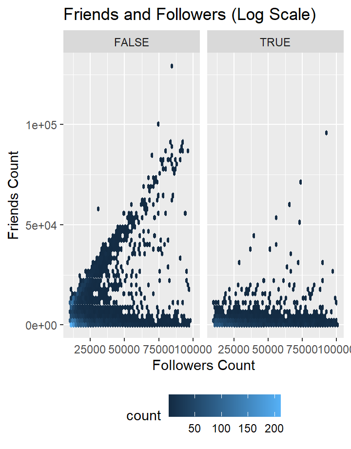

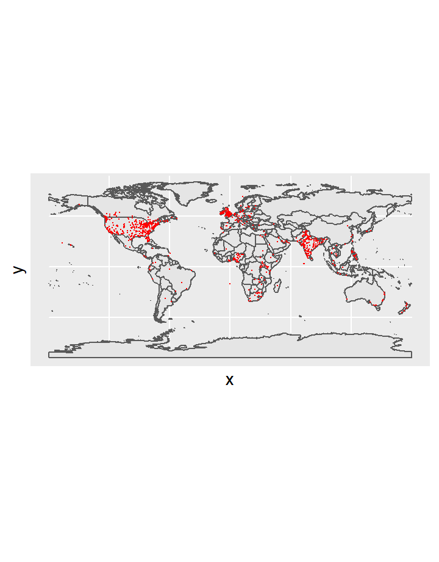

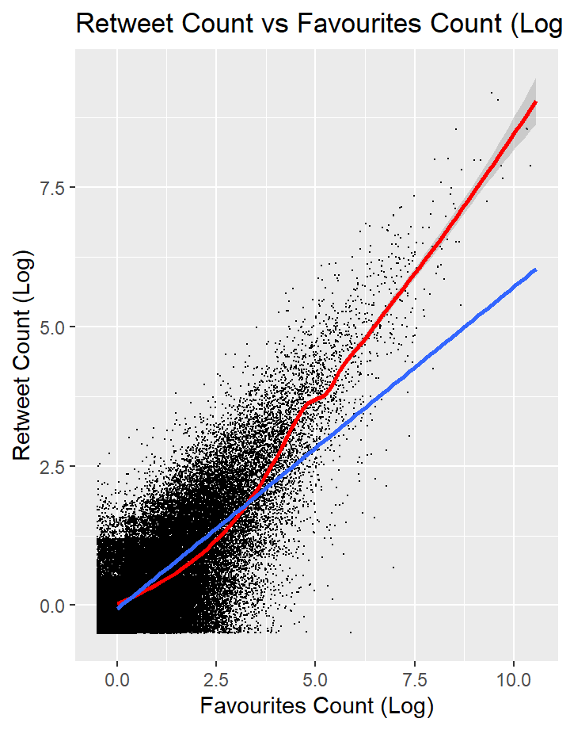

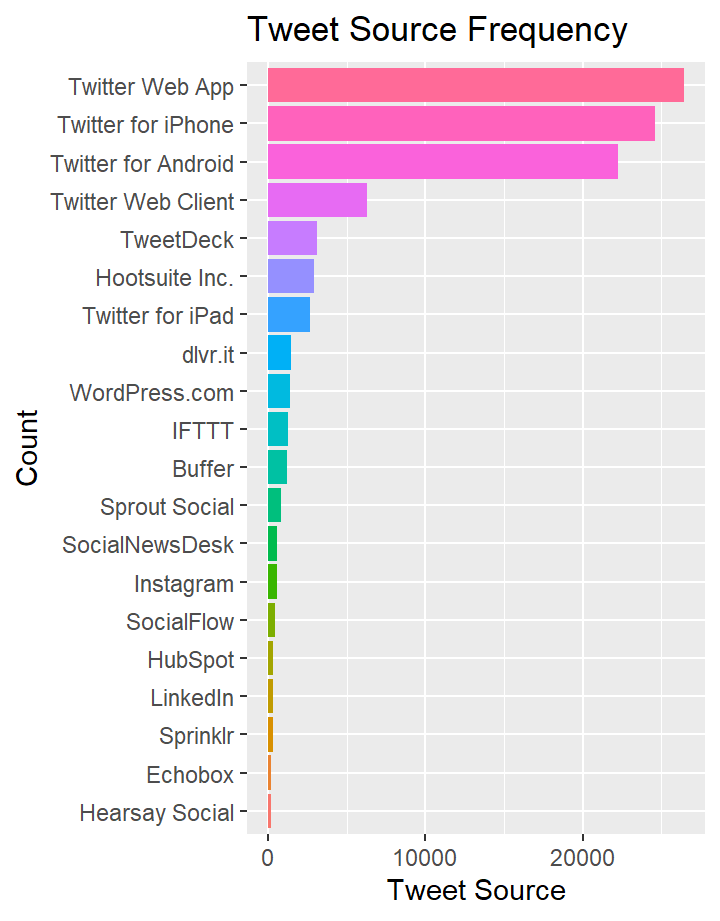

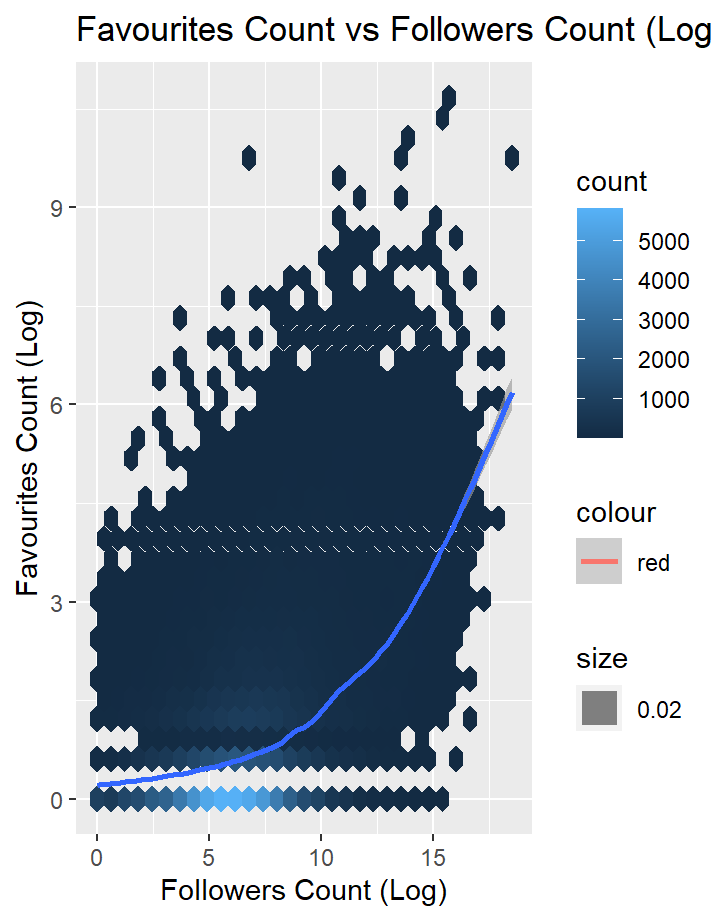

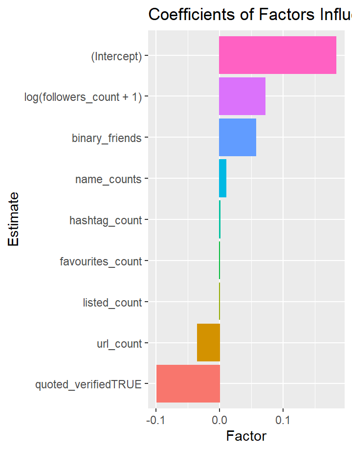

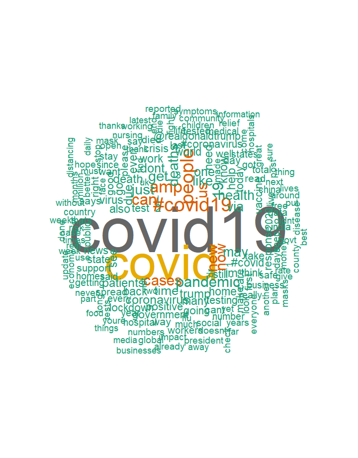

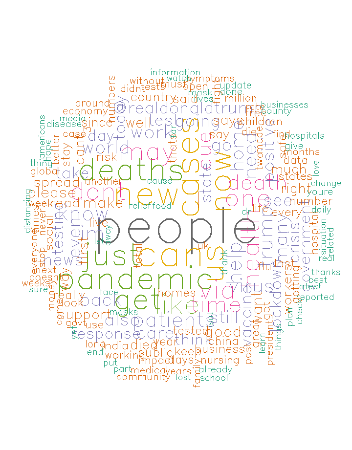

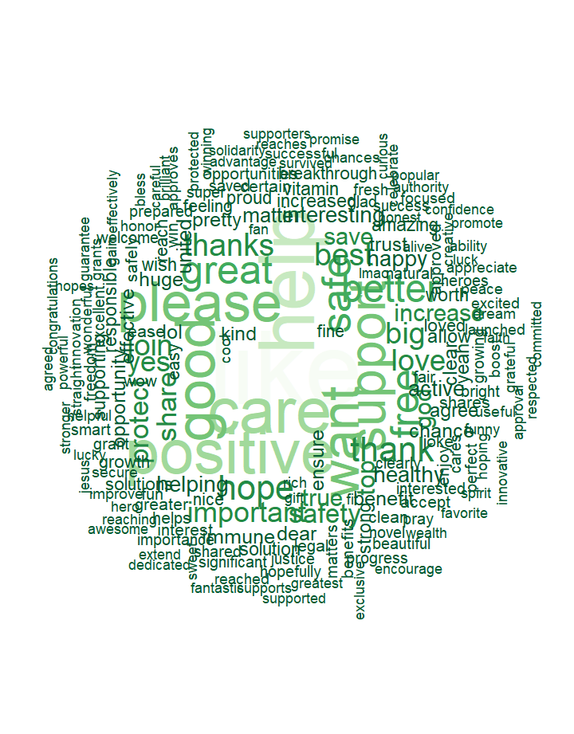

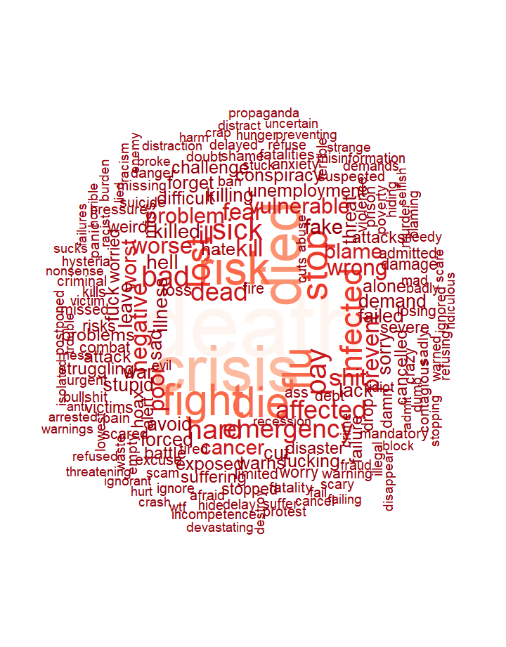

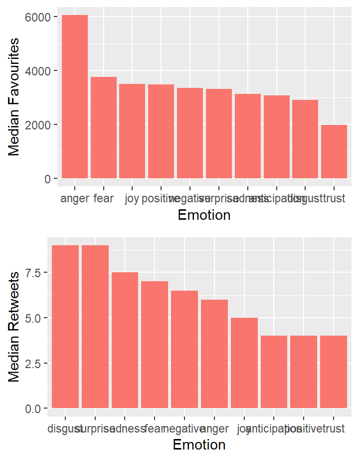

[5 more figures not shown]

# 0. About

### Data Introduction

Our dataset contains the metadata for over 104000 tweets which mentioned “covid”. The majority of the tweets are dated to the 15th of May 2020, which is when the data was scraped from Twitter. The dataset was cleaned and extended to include variables relating to the sentiment of the words in each tweet.

### Data Downloading

The bulk of the data we have used consists of tweets. These were sourced through the Twitter API and are mostly from the 15th of May. The data was downloaded in 7 batches, each with slightly under 15,000 tweets. Each batch of downloads was saved as a file called ‘tweets_n.rds’ which can be found in the ‘data’ folder. The format of the downloads is captured in ’00-downloading-tweets.Rmd’. Note that using the Twitter API requires a free private developer license, so the code is not usable without a private key. It is also only possible to download tweets up to a week in the past, so the exact dataset that we have used in our project cannot be reproduced.

# 1. Data Cleaning

### Data Cleaning

**Stage 1: Initial Data Cleaning**

Read and combine data…

```r
saved_data_1 <- readRDS(file = "tweets_1.rds")
saved_data_2 <- readRDS(file = "tweets_2.rds")
saved_data_3 <- readRDS(file = "tweets_3.rds")
saved_data_4 <- readRDS(file = "tweets_4.rds")
saved_data_5 <- readRDS(file = "tweets_5.rds")
saved_data_6 <- readRDS(file = "tweets_6.rds")
saved_data_7 <- readRDS(file = "tweets_7.rds")
saved_data <- rbind(saved_data_1,saved_data_2,saved_data_3,saved_data_4,saved_data_5,saved_data_6,saved_data_7)
# add an index column
saved_data$index <- 1:nrow(saved_data)
# add a time of day column
saved_data<- saved_data%>% mutate(time=hms(created_at))
```

Get the numbers of specific things that are mentioned in the tweets…

```r
# add a column with the number of hashtags present in a document
saved_data <- saved_data %>%
  select(index, hashtags) %>%
  unnest(hashtags) %>%
  filter(!is.na(hashtags)) %>%
  group_by(index) %>%
  summarise(hashtag_count = n()) %>%
  right_join(saved_data) %>%
  mutate(hashtag_count = ifelse(!is.na(hashtag_count), hashtag_count, 0))
# add a variable for the number of mentioned screen names in a tweet
saved_data<-saved_data %>%
  select(index,mentions_screen_name) %>%
  unnest(mentions_screen_name) %>%
  filter(!is.na(mentions_screen_name)) %>%
  group_by(index) %>%
  summarise(name_counts=n()) %>%
  right_join(saved_data) %>%
  mutate(name_counts=ifelse(!is.na(name_counts),name_counts,0))
# add a variable for the number of mentioned urls
saved_data<-saved_data %>%
  select(index,urls_url) %>%
  unnest(urls_url) %>%
  filter(!is.na(urls_url)) %>%
  group_by(index) %>%
  summarise(url_count=n()) %>%
  right_join(saved_data) %>%
  mutate(url_count=ifelse(!is.na(url_count),url_count,0))
# add binary variables for if the tweet had any favourites and if they mentioned more than 1 friend
saved_data<- saved_data %>%
  mutate(engagement_binary=ifelse(favorite_count>0,1,0)) %>%
  mutate(binary_friends=ifelse(name_counts>1,1,0))
```

Select only variables that could be useful…

```r
intermediate_step<- saved_data %>%
  select(c("index","user_id","status_id","created_at","screen_name","text","source","display_text_width","is_quote","reply_to_screen_name","favorite_count","retweet_count","lang","quoted_name","quoted_followers_count","quoted_verified","place_type","country","country_code","bbox_coords","coords_coords","location","description","followers_count","friends_count","listed_count","statuses_count","favourites_count","account_created_at","verified","hashtag_count","engagement_binary","binary_friends","name_counts","url_count"))
```

**Stage 2: Adding Sentiment Information**

Tokenise the text data to get the number of sentiment words…

```r
# create a separate text data frame
text_data<-intermediate_step %>%
  select(c("index","text")) %>%
  unnest_tokens(output = word,input = text,token = "words",to_lower=TRUE)
```

Count the number of words in each tweet so we can standardise the sentiment later…

```r
word_counts<-text_data %>%
  group_by(index) %>%
  summarise(num_words=n())
```

Use the text dataframe to get sentiment word numbers for each tweet…

```r
sentiments<- get_sentiments("nrc")
tidy_tweets_sentiment <-text_data %>%
  inner_join(sentiments) %>%
  group_by(index,sentiment) %>%
  summarise(count=n()) %>%
  pivot_wider(names_from=c("sentiment"),values_from=count)
# impute zeros into sentiment data
tidy_tweets_sentiment[is.na(tidy_tweets_sentiment)] <- 0
```

Get the average positivity of the words in a tweet…

```r
sentiments<- get_sentiments("afinn")
tidy_tweets_positive <-text_data %>%
  inner_join(sentiments)%>%
  group_by(index)%>%
  summarise(average_positive_sentiment=mean(value))
```

Join information into a single table and save results…

```r
tweets_with_sentiment<-left_join(intermediate_step,word_counts) %>%
  left_join(tidy_tweets_sentiment)%>%left_join(tidy_tweets_positive)
saveRDS(tweets_with_sentiment, file = "tweets_final")
```

**Stage 3: Adding Location Information**

Extract tweet locations from dataframe…

```r
get_locations<-function(input_data){
  geo_locations<-input_data %>%
  select(c("bbox_coords","location","index")) %>%
  unnest_wider(bbox_coords,names_repair = "minimal",names_sep="_") %>%
  filter(!is.na(`bbox_coords_...1`)) %>%
  mutate(x=(bbox_coords_...1+bbox_coords_...2+bbox_coords_...4+bbox_coords_...3)/4,
         y=(bbox_coords_...5+bbox_coords_...6+bbox_coords_...7+bbox_coords_...8)/4) %>%
  select(c("location","index","x","y"))
  return(geo_locations)
}
geo_locations <- tweets_with_sentiment %>%
  filter(index<300) %>%
  get_locations()
for (i in 3:1050) {
  print(i)
  temp_locations <- tweets_with_sentiment %>%
    filter(index>=100*i&index<100*(i+1)) %>%
    get_locations()
  geo_locations <- geo_locations %>%
    bind_rows(temp_locations)
}
geo_locations
saveRDS(geo_locations, file = "geo_locations_of_tweets.rds")
```

Load covid data so we can match it to tweet location…

```r
covid_data<-read_csv(file="owid-covid-data.csv") %>%
  filter(yday(date)==yday("2020-05-20")) %>%
  select(location,date,total_cases,new_cases,total_deaths,new_deaths,total_cases_per_million,new_cases_per_million,new_deaths_per_million,population,population_density,median_age)
```

Load geographical data and define a function that returns the closest country to each tweet’s location. Note that this process only allows for rough estimates.Mutate the closest country as a new column…

```r
location_data<-read_excel("geo_countries.xlsx")

# find the closest country to a pair of lattitude and longitude coordinates
min_country<-function(x,y){
  min_country<-"no_country_yet"
  minval<-100000
  for(i in 1:240){
    a=((x-location_data$Longitude[i])^2+(y-location_data$Latitude[i])^2)
    min_country<-ifelse(a<minval,location_data$Country[i],min_country)
    minval<-ifelse(a<minval,a,minval)
  }
  return(min_country)
}
geo_locations<-geo_locations%>%mutate(closest_country=min_country(x,y))
```

Join the locations and the covid data, save the results…

```r
tweet_location_character<- left_join(geo_locations,covid_data,by=c("closest_country"="location"))
saveRDS(tweet_location_character, file = "geo_characteristics_of_tweets.rds")
```

# 2. Twitter Accounts

### 2a. Introduction

In this section, we will look at the different characteristics of the unique Twitter accounts in our dataset.

### 2b. Unique Twitter Accounts

Let’s start by looking at the Twitter accounts in our dataset with the most followers.

| screen_name | followers_count | friends_count | statuses_count | covid_tweets |
| --- | --- | --- | --- | --- |
| katyperry | 108502854 | 223 | 10689 | 1 |
| CNN | 48123941 | 1107 | 301394 | 3 |
| nytimes | 46570506 | 909 | 396542 | 1 |
| BBCWorld | 28082723 | 71 | 309863 | 1 |
| TheEconomist | 24787902 | 125 | 214402 | 13 |
| Reuters | 21946326 | 1116 | 532091 | 11 |
| WSJ | 17767881 | 925 | 307795 | 5 |
| TIME | 17131178 | 495 | 347479 | 2 |
| Forbes | 16030003 | 5288 | 242719 | 2 |
| ABC | 15588417 | 529 | 302312 | 6 |

The accounts with the most followers are generally news channels, but it is interesting that Katy Perry, a celebrity, made it into our dataset.

### 2c. Relationship between Verified Accounts & Followers Count (Introduction)

Let’s look at the amount of verified and unverified accounts in our dataset.

| verified | total | percentage |
| --- | --- | --- |
| FALSE | 78690 | 0.9372878 |
| TRUE | 5265 | 0.0627122 |

Nearly 94% of the unique accounts in our dataset are unverified and only around 6% of the unique accounts are verified. It will be interesting to see if there is a difference in tweet engagement or sentiment for tweets that are verified or unverified.

Let’s now look at the distribution for the number of followers and see how this varies with verified and unverified accounts.

```
          0%          25%          50%          60%          70%          80%
        0.00        94.00       476.00       859.00      1579.00      3312.00
         90%          95%        97.5%         100%
    10056.20     27127.60     72872.35 108502854.00
```

By looking at the quantiles for number of followers, it is clear that there is a very strong positive skew. Around 50% of people have more than ~476 followers, around 10% of people have more than ~10000 followers, but only around 2.5% of people have more than ~73,000 followers.

### 2c. Relationship between Verified Accounts & Followers Count (Plot)

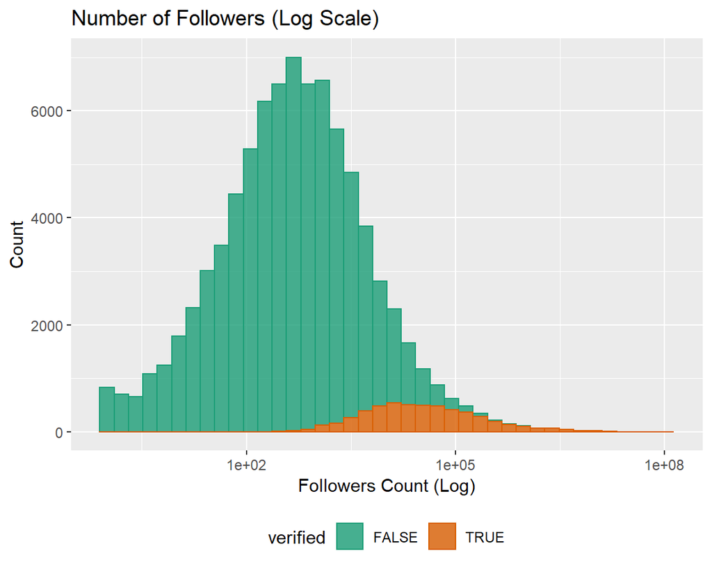

### 2c. Relationship between Verified Accounts & Followers Count (Discussion)

After plotting the distribution of followers on a logarithmic scale, it’s clear that as the amount of Twitter account followers increases, the proportion of these accounts which are verified also increases. In other words, larger and more high profile Twitter accounts are more likely to be verified, and smaller accounts are less likely to be verified.

### 2d. Friends & Followers Ratio (Introduction)

Let’s see how a Twitter accounts number of friends and followers are related. Let’s specifically look at accounts with between 10,000-100,000 followers, which should represent accounts which are not too small, but also not too big.

### 2d. Friends & Followers Ratio (Plot)

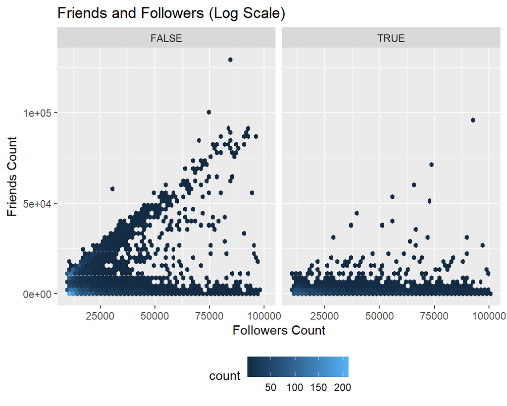

### 2d. Friends & Followers Ratio (Discussion)

The hex plot of friends and followers indicates that for the same amount of followers, unverified accounts are likely to have many more friends than verified accounts.

An interesting relationship also seems to be visible in the followers and friends plot for unverified users. Along the upper boundary, there appears to be near 1:1 relationship between followers and friends. That is, a lot of unverified Twitter accounts have a very similar amount of friends and followers.

Let’s look into this relationship by investigating accounts with more than 50,000 friends. Then, let’s create a ratio of number of followers divided by number of friends, and look at this relationship in a table:

| ratio (mean) | ratio (median) |
| --- | --- |
| 3.290861 | 1.089488 |

### 2e. Location of tweets

Where are the tweets situated globally?

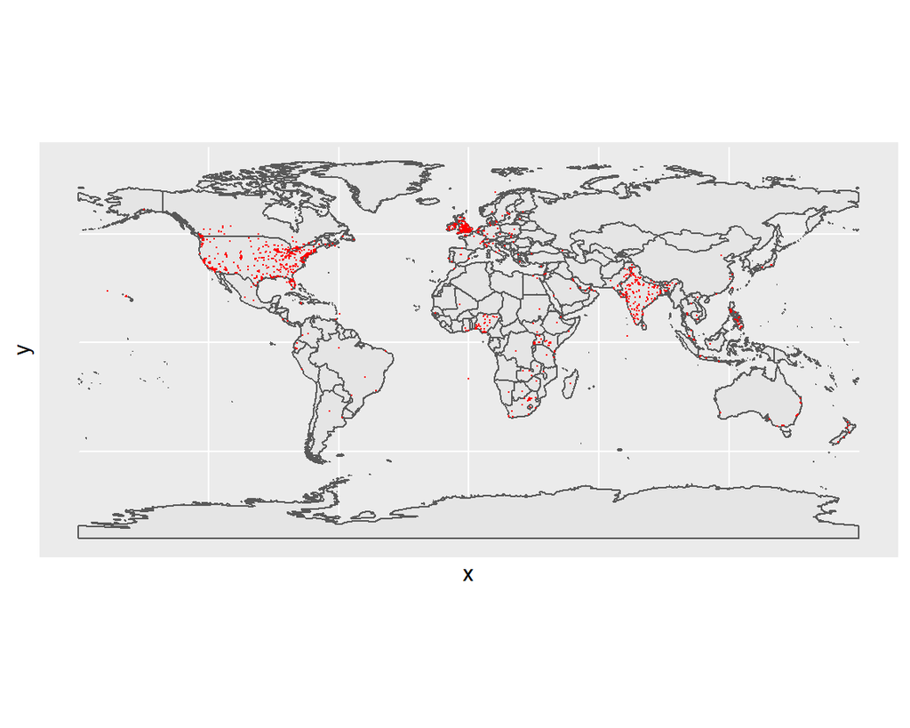

### 2e. Location of tweets (discussion)

Note: It is likely that tweets from Mexico are overestimated.

# 3. Tweet Engagement

### 3a. Introduction

In this section, we will look at how the different characteristics of a tweet are reflected in its level of engagement. This engagement is measured by looking at the amount of retweets and favourites.

### 3b. Relationship between Likes and Retweets (Plot)

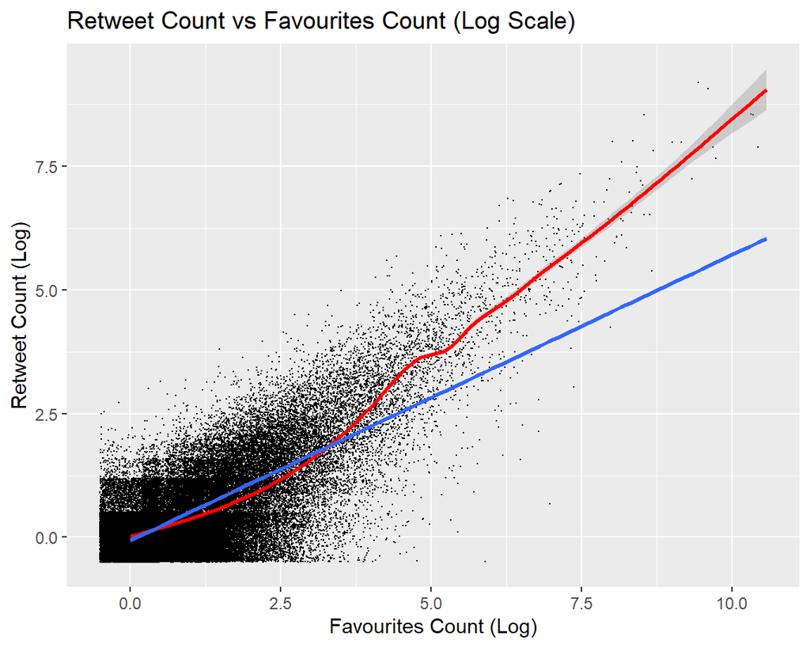

### 3b. Relationship between Likes and Retweets (Discussion)

The vast majority of tweets have very few likes and retweets and are situated in the bottom left hand corner. The blue line is the least squares estimate of the linear relationship between the logarithm of likes and retweets in our dataset. The red line is a smoothed trendline of the relationship between likes and retweets.

In general as the number of likes increase, so does the number of retweets. However, we can see that the most popular tweets fall above the linear trend line, indicating that they are recieving disproportionately more shares relative to the number of likes, compared to an ordinary tweet.

### 3c. Tweet Source (Plot)

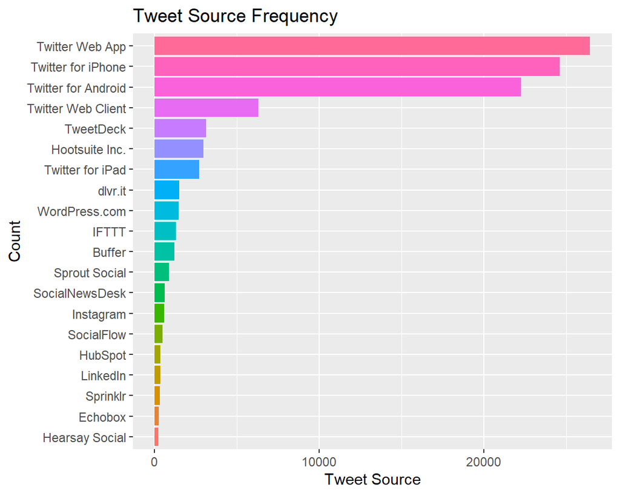

### 3c. Tweet Source (Discussion)

We can see that the vast majority of tweets come from either laptops or mobile devices. However, there are also many other sources of tweets that are likely a combination of marketing services, and social media aggregation apps. For example, Hootsuite is a social media management platform. Only the top 20 platforms have been included in the graph, but there are 1237 sources in the dataset.

### 3d. Relationship between Followers and Favourites (Plot)

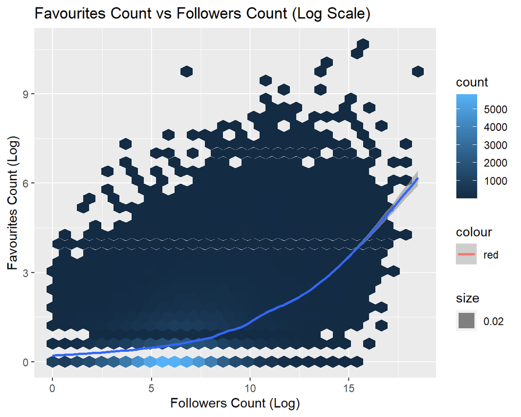

### 3e. Factors Influencing Likes (Plot)

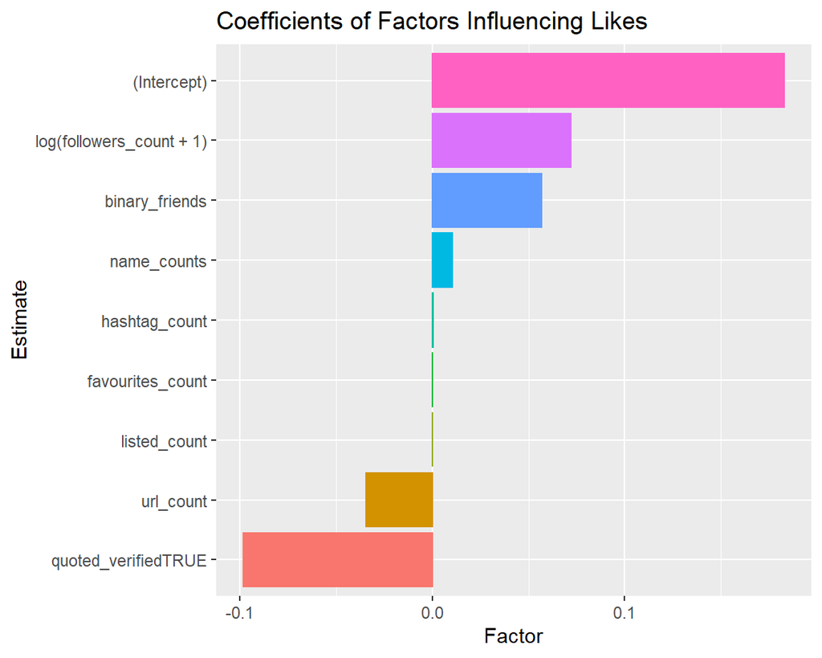

### 3e. Factors Influencing Likes (Discussion)

# 4. Word Clouds

### 4a. Introduction

In this section, we will look at the most commonly used words in the tweets that make reference to ‘covid’.

### 4b. Word Cloud 1 (Plot)

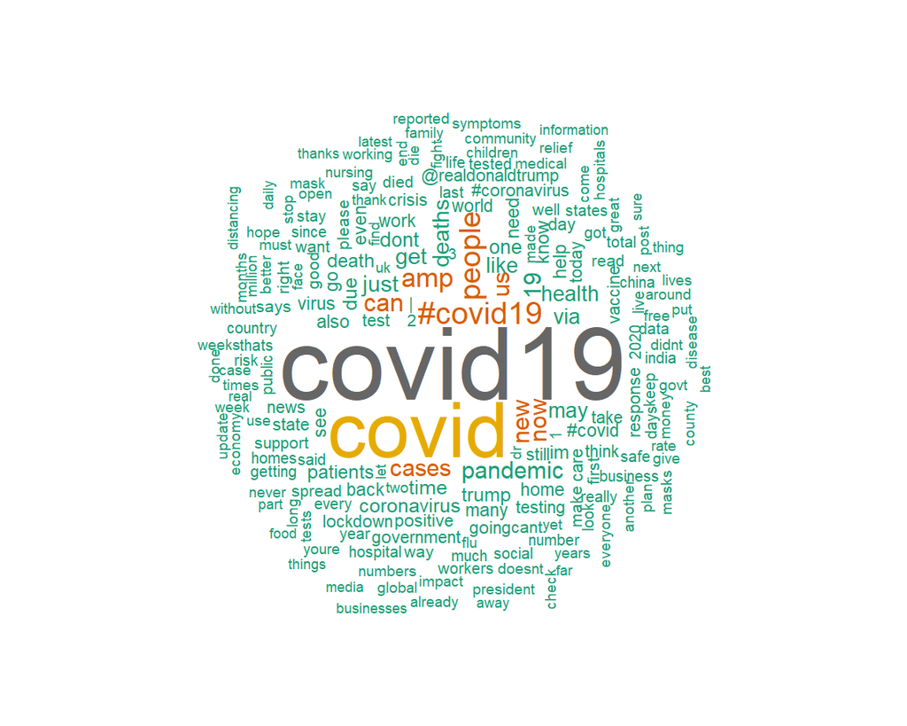

### 4b. Word Cloud 1 (Discussion)

Firstly, the data was tokenised by tweets which preserves usernames, hashtags and HTML’s in order to not remove any data that me be useful in tweets. By filtering this way instead of tokenizing by ‘words’ like initially completed in the data cleaning, it was able to be found that the username @realdonaldtrump was frequently mentioned with the word ‘covid’.

### 4c. Word Cloud 2 (Plot)

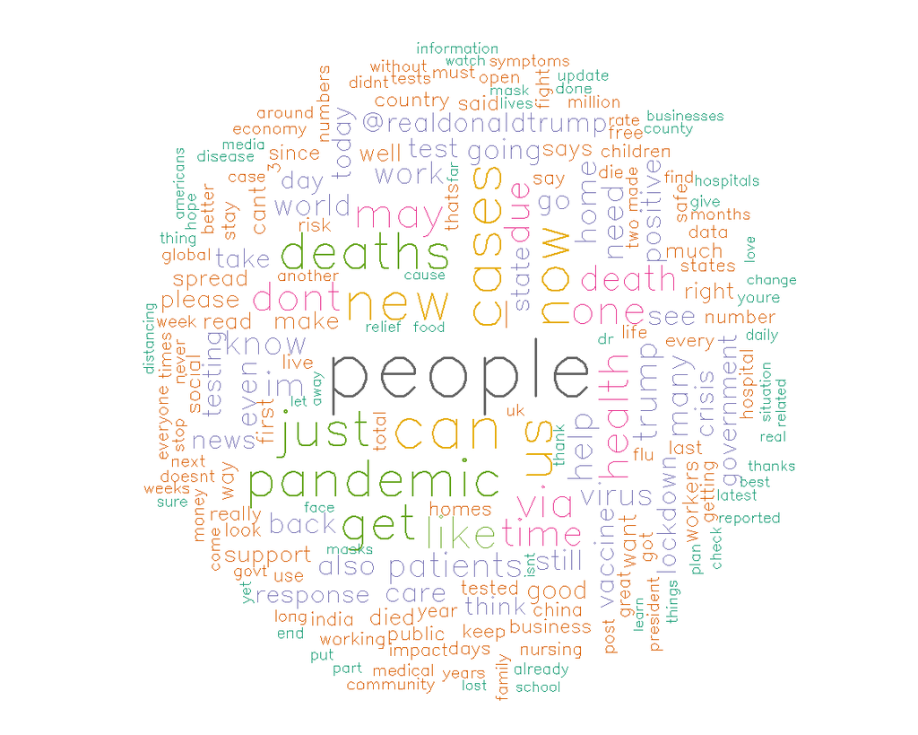

### 4c. Word Cloud 2 (Discussion)

Further cleaning was taken to remove numbers and symbols which are not removed by this tokenizing procedure. Additionally, words synonymous with or variations of ‘covid’ were removed from the data. The most used word in tweets containing ‘covid’ is the word ‘people’ which has no sentiment related to it. However, common words including ‘like’ which has a positive sentiment and ‘deaths’ which has a negative sentiment are both frequently used in ‘covid’ tweets

This analysis of the most used words suggests that tweets about ‘covid’ may both be written with positive or negative connotations. However, the overarching concern is neutral word ‘people’, possibly because individuals have both the potential to positively affect the control of the virus as well as to be negatively affected by the outbreak of the virus.

### 4c. Word Cloud Positive Sentiment (Plot)

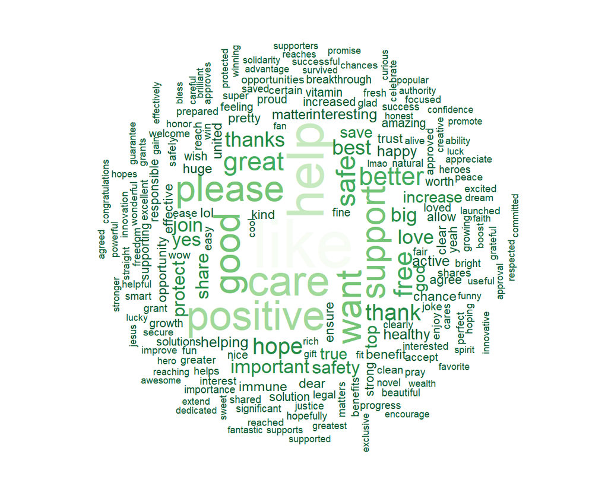

### 4d. Wordcloud Negative Sentiment

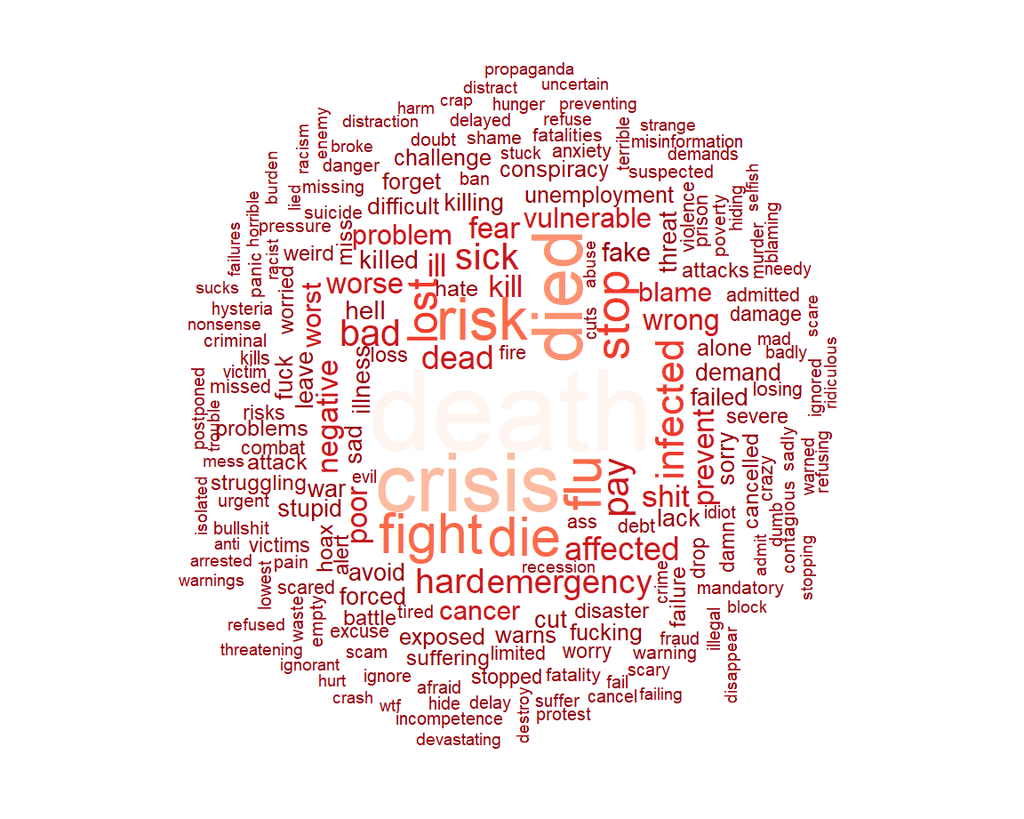

### 4d. Word Cloud Positive and Negative Sentiment (Discussion)

Finally, the words were categorised using the lexicon ‘afinn’ and then filtered based on being greater or less than 0 to create separate word clouds containing only positive or negative sentiment words. The central positive words used were ‘like’, ‘help’ and ‘care’ and the main negative words used were ‘death’, ‘crisis’ and ‘died’.

It can be seen that the top positive and negative sentiment words are likely to be paired with ‘people’. ‘People’ have the ability to ‘care’ and ‘help’ the virus to reduce its spread. However, ‘people’ may also ‘die’ or experience ‘death’ around them as a result of the outbreak. This supports the analysis on the word ‘people’ and emphasises how individuals collectively can be being tweeted about in both a positive or negative sentiment in relation to COVID-19.

# 5. Sentiment Analysis

### 5a. Introduction

In this section, we will look at relationship between the sentiment expressed in a tweet and the level of engagement it received.

### 5c. Tweets with Strong Sentiment (Introduction)

Let’s wrap up this analysis by looking at how the level of engagement of a tweet was related to the emotional sentiment in a tweet. In our dataset, we have 10 different emotions in the ‘nrc’ library and we can investigate the tweets which expressed the largest quantity of these emotions. We have written a function that, for a given emotional sentiment, extracts the tweets with the most words of that sentiment. The results are summarised and expressed below.

| emotion | favourites (median) | followers (median) | tweets_extracted |
| --- | --- | --- | --- |
| disgust | 3953.5 | 272.5 | 1262 |
| anger | 3577.0 | 251.0 | 585 |
| negative | 3441.5 | 241.5 | 864 |
| surprise | 2737.0 | 300.0 | 969 |
| sadness | 2681.0 | 283.0 | 1146 |
| fear | 2671.0 | 213.5 | 634 |
| anticipation | 1878.5 | 380.0 | 1062 |
| positive | 1553.0 | 448.0 | 1105 |
| trust | 1550.0 | 334.0 | 720 |
| joy | 1398.0 | 605.0 | 587 |

The table above shows us the output of our function which extracted the tweets with the most words of each emotional sentiment. The median amount of favourites of these tweets is shown, the median amount of followers for the account making these tweets is shown, and the amount of tweets extracted for the emotion is also shown.

It looks like the tweets which displayed strong amounts of disgust, anger, negative and surprise were the ones which were the most favourited. Tweets which displayed strong amounts of positivity, trust and joy were the ones with the least amount of favourites.

Let’s now look at the tweets with the most words of each emotional sentiment for verified accounts. Since verified accounts generally have more engagement, we can look at the amount of favourites of the tweets as well as the amount of retweets.

### 5c. Tweets with Strong Sentiment (Plot)

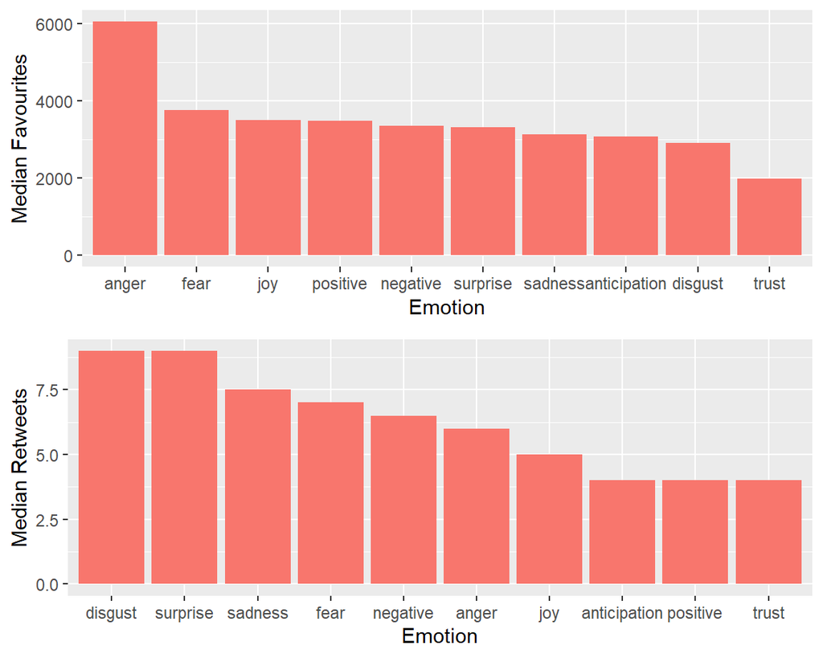

### 5c. Tweets with Strong Sentiment (Discussion)

Here, it is very clear that tweets from verified accounts which displayed large amount of anger and fear received the most favourites. Tweets which displayed the largest amount of trust received the least favourites.

Tweets which displayed a large amount of disgust, surprise and sadness received the most retweets, while tweets which displayed the most positivity and trust received the least retweets.

From this analysis of emotional sentiment, it appears that tweets which feature the most negative sentiment have the most engagement. This may be because the tweets with negative sentiment are more attention grabbing, create more fear, and invoke other emotional response in viewers.

### 5d. Relationship between Sentiment and Likes (Plot)

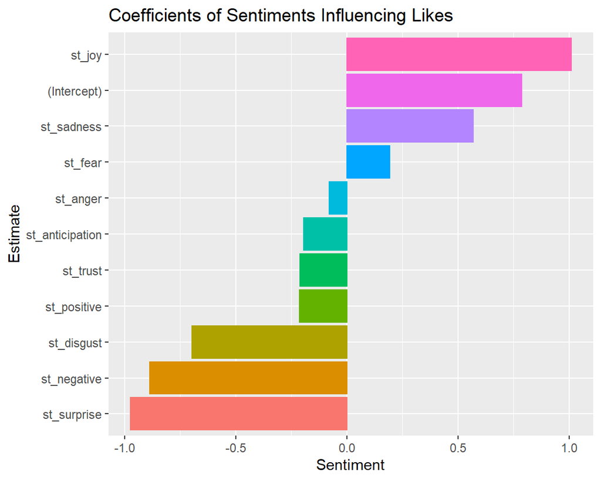

### 5d. Relationship between Sentiment and Likes (Discussion)

The above graph shows how different sentiments effect the logarithm of the expected number of likes a tweet in our dataset will get. We see that joy, sadness and fear tend to increase the number of likes a tweet recieves. conversely, tweets expressing anger, anticipation, trust, and positivity perform slightly below average. Tweets with disgust, negativity, and surprise performed the worst.

# 6. Nation Analysis

### 6a. Introduction

In this section, we will look at which nations are tweeting the most about Covid-19 and the sentiment that more affected nations express.

### 6b. Top Tweeting Nations (Plot)

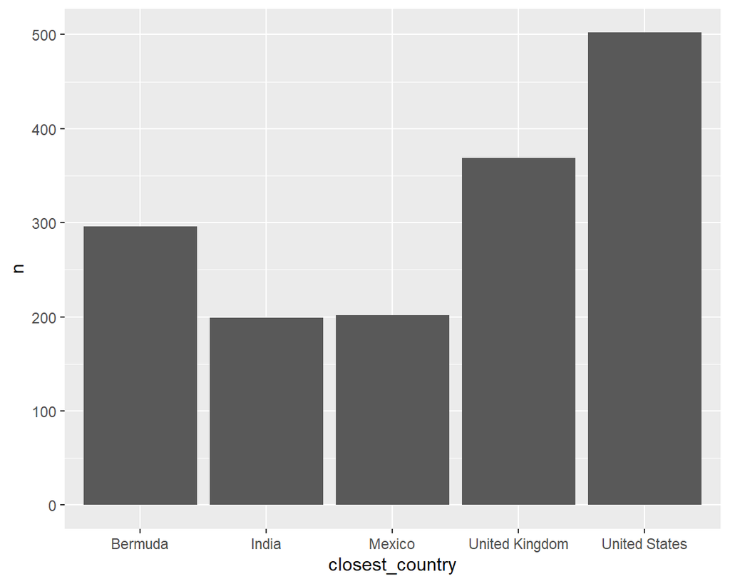

### 6b. Top Tweeting Nations (Discussion)

First, we want to gather a quick summary of which countries are most actively using Twitter to discuss Covid-19. To do this we obtain a count of number of Tweets made in each nation and graph it. Based on our output, these are the top 5 nations who are tweeting about Covid-19. This is able to provide an overview about which nations are most involved with discussions of Covid-19 via the internet. It is interesting to see that Bermuda, with such a small population in relation to the other top 5 nations has had such a significant number of Tweets.

Following this, we can look at the nations that are tweeting the most per capita to gather insight on which countries are tweeting the most in proportion to their population.

### 6c. Top Tweeting Nations Per 10,000 (Plot)

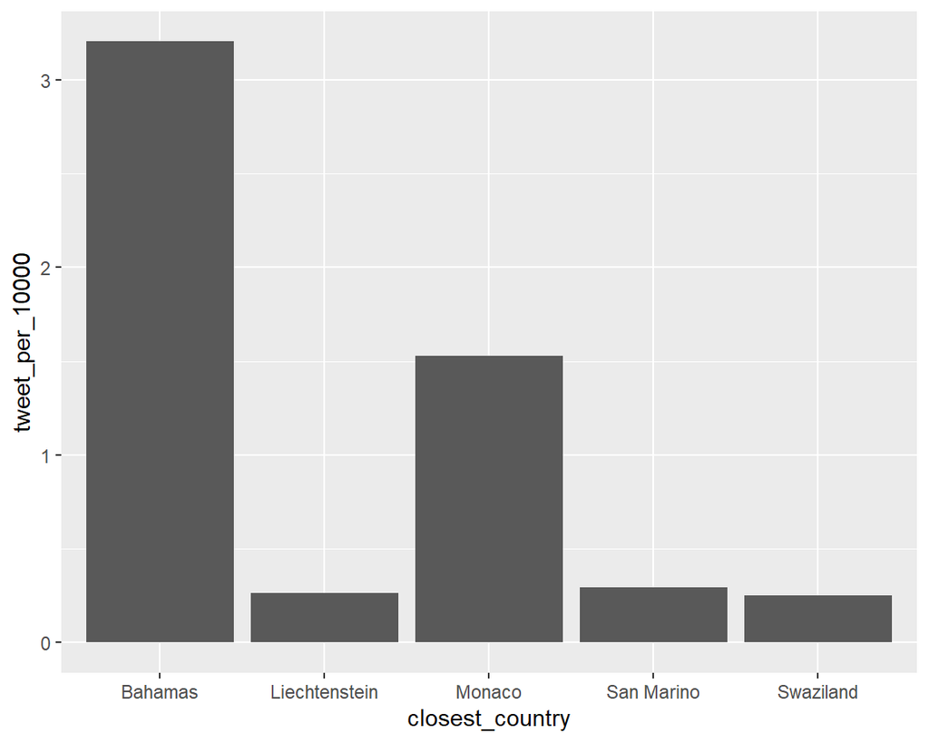

### 6c. Top Tweeting Nations Per 10,000 (Discussion)

In this output, we can see that the Bahamas has the highest number of tweets per 10,000 people by a significant amount. Following the Bahamas is Monaco with approximately 1.5 tweets per 10,000 with the remaining three countries having much lower levels of tweeting per capita.

Following this information, we want to determine whether a negative sentiment is expressed in the Tweet data for all nations. We would expect that nations with lower levels of Covid infectivity would express less negative sentiment than that of nations who are more negatively affected by the effects of Covid-19. It will also be interesting to see whether the nations represented in the charts above express a more positive or negative sentiment. This data can be presented on a map.

### 6d. Total Cases Per Million (Map)

```
200 codes from your data successfully matched countries in the map
5 codes from your data failed to match with a country code in the map
43 codes from the map weren't represented in your data
```

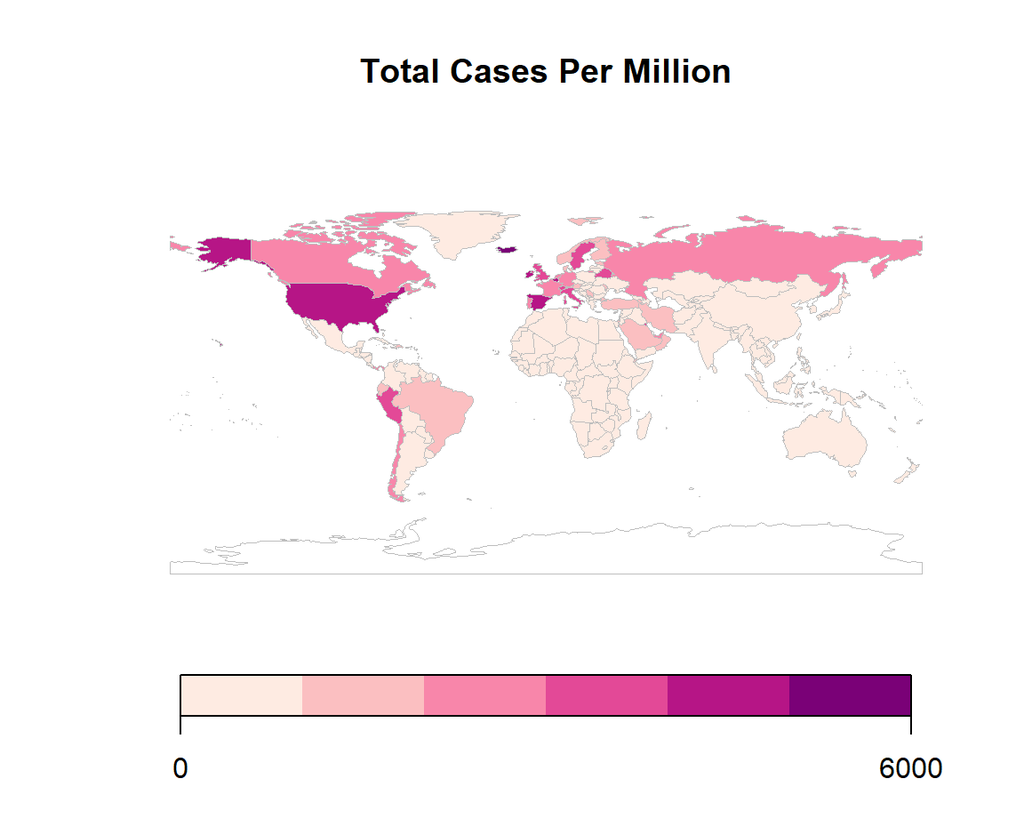

### 6d. Total Cases Per Million (Discussion)

Note: When Interpreting these maps, locations are based on estimates on coordinates.

Using this information, we can also map the average sentiment by nation and view the relationship between the size of an outbreak within a nation, and the emotional expression in tweets from that nation. We would expect to see a relationship between countries with higher outbreaks and more negative expression in the tweets.

### 6e. Postive Sentiment and Total Cases Per Million (Map)

```
2763 codes from your data successfully matched countries in the map
5 codes from your data failed to match with a country code in the map
43 codes from the map weren't represented in your data
```

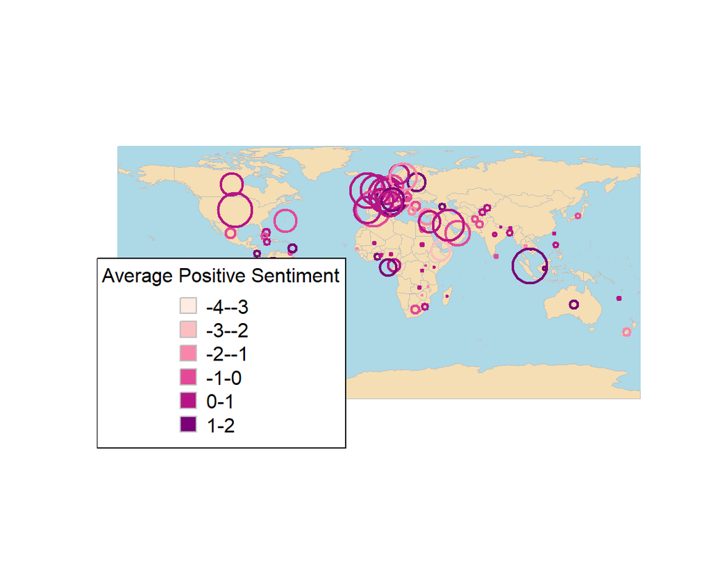

### 6e. Postive Sentiment and Total Cases Per Million (Discussion)

Overall it is interesting to see that nations who are more greatly affected by Covid-19 still show high levels of positive sentiment. It is also worth noting that the countries that are tweeting the most, in particularly the United Kingdom and the United States, express high levels of positive sentiment which would suggest that tweets generally show positive sentiment. There does not seem to be a clear relationship between higher levels of outbreak and negative sentiment as previously beleived which would imply that Covid-19 impact in a nation does not necessarily affect the positivity of its population.